# 時系列分析 第 10 回

見せかけの回帰と共和分

Kenichiro Tamaki

2022 年 6 月 13 日

# 6 見せかけの回帰と共和分

## 6.1 見せかけの回帰

> **定義6.1 (見せかけの回帰, p.127)**
> 時系列回帰分析
> $$y_{t} = \alpha + \beta x_{t} + \varepsilon_{t}$$
> を考える. $x_{t}$ と $y_{t}$ が単位根過程の場合, 関係がなくても, あたかも関係があるかのような結果が得られる場合があり, この現象を見せかけの回帰 (spurious regression) という.

傾向として

- 係数が有意になる ($t$ 値が大きくなり, $p$ 値は小さくなる)
- 決定係数が大きい

経済・ファイナンス分野では単位根をもつデータが多いので, 注意しなければならない.

**例**

```r
T <- 200 # 標本数
set.seed(9) # 乱数を指定
x <- cumsum(rnorm(T)) # ランダム・ウォーク
y <- cumsum(rnorm(T)) # ランダム・ウォーク
cor(x, y) # 相関係数
```

```
## [1] -0.8100613
```

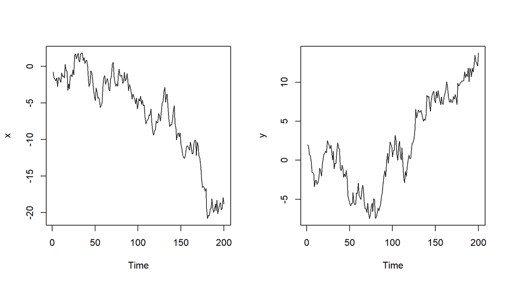

```r
par(mfrow = c(1, 2)) # プロット画面を 1 行 2 列に分割
ts.plot(x); ts.plot(y) # 時系列プロット
```

被説明変数を $y$, 説明変数を $x$ として回帰分析を行う.

```r
sr <- lm(y ~ x) # 回帰分析
summary(sr) # 結果を表示
```

```
##
## Call:
## lm(formula = y ~ x)
##
## Residuals:
##     Min      1Q  Median      3Q     Max
## -7.1715 -2.5691  0.1621  2.3207  6.9431
##
## Coefficients:
##             Estimate Std. Error t value Pr(>|t|)
## (Intercept) -2.78994    0.34744   -8.03 8.52e-14 ***
## x           -0.76194    0.03919  -19.44  < 2e-16 ***
## ---
## Signif. codes:  0 '***' 0.001 '**' 0.01 '*' 0.05 '.' 0.1 ' ' 1
##
## Residual standard error: 3.372 on 198 degrees of freedom
## Multiple R-squared:  0.6562, Adjusted R-squared:  0.6545
## F-statistic: 377.9 on 1 and 198 DF,  p-value: < 2.2e-16
```

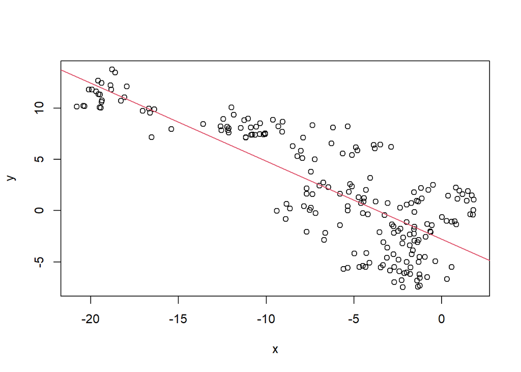

```r
plot(x, y) # 散布図
abline(sr, col = 2) # 回帰直線
```

定数項, 回帰係数ともに有意水準 $1 \%$ で有意であり, 決定係数も高いので, 関係があるように見える.

差分系列を考える.

```r
x.d <- diff(x) # x の差分系列
y.d <- diff(y) # y の差分系列
cor(x.d, y.d) # 相関係数
```

```
## [1] 0.0438177
```

```r
summary(lm(y.d ~ x.d)) # 回帰分析
```

```
##
## Call:
## lm(formula = y.d ~ x.d)
##
## Residuals:
##      Min       1Q   Median       3Q      Max
## -2.54902 -0.57423 -0.06736  0.67471  2.66284
##
## Coefficients:
##             Estimate Std. Error t value Pr(>|t|)
## (Intercept)  0.06303    0.06941   0.908    0.365
## x.d          0.04383    0.07120   0.616    0.539
##
## Residual standard error: 0.9749 on 197 degrees of freedom
## Multiple R-squared:  0.00192,    Adjusted R-squared:  -0.003146
## F-statistic: 0.379 on 1 and 197 DF,  p-value: 0.5389
```

定数項, 回帰係数ともに有意でなく, 決定係数も低いので, 関係はない.

**回避方法*

- 方法1: ラグ変数を説明変数に含める

$$y_{t} = \alpha + \beta_{1} x_{t} + \beta_{2} x_{t - 1} + \beta_{3} y_{t
- 1} + \varepsilon_{t}$$

- 方法2: 差分をとり, 定常過程に変換してから用いる

$$\Delta y_{t} = \alpha + \beta_{1} \Delta x_{t} + \varepsilon_{t}$$

- 差分をとる場合の注意
  - 過剰差分
  - 共和分関係

## 6.2 共和分

> **定義6.2共和分 (, p.129)**  
> $x_{t}$ と $y_{t}$ を $I(1)$ 過程とする. $a x_{t} + b y_{t}$ が $I(0)$ 過程となる $a$, $b$ が存在するとき, $x_{t}$ と $y_{t}$ の間に共和分関係 (cointegration) があるといい, $(a,b)^{\prime}$ を共和分ベクトルという.  
> 一般的には, $\boldsymbol{y}_{t}$ を $I(1)$ 過程とする. $\boldsymbol{a}^{\prime} \boldsymbol{y}_{t}$ が $I(0)$ 過程となる $\boldsymbol{a}$ が存在するとき, $\boldsymbol{y}_{t}$ に共和分関係があるといい, $\boldsymbol{a}$ を共和分ベクトル (cointegrating vector) という.

一般的に単位根過程の線形和は単位根過程であるが, 共和分関係がある場合は定常過程になる.

**共和分ベクトル**

共和分ベクトルは一意には定まらない.

- $(a,b)^{\prime}$ を共和分ベクトルとすると, $(2a, 2b)^{\prime}$ も共和分ベクトルである
- 基準化: 最初の成分を $1$ にする $(1, b / a)^{\prime}$

**共和分ランク**

$w_{1, t}$, $w_{2, t}$ を互いに独立な単位根過程, $u_{1, t}$, $u_{2, t}$ を互いに独立な定常過程とする.

**例6.1 (p.130)**

$$\begin{cases}
x_{t} = \alpha w_{1, t} + u_{1, t} \\
y_{t} = \beta w_{1, t} + u_{2, t} \\
\end{cases}$$

このとき, $x_{t}, y_{t} \sim I(1)$ であるが

$$x_{t} - \frac{\alpha}{\beta} y_{t} = u_{1, t} - \frac{\alpha}{\beta}
u_{2, t} \sim I(0)$$

より, $x_{t}$ と $y_{t}$ の間に共和分関係があり, 共和分ベクトルは $(1, -\alpha / \beta)^{\prime}$ である. 共和分関係がある変数に対して差分を用いて回帰分析を行うと, 長期的な関係があるにも関わらず, これを考慮しない短期的な関係のみが得られる.

**例6.2 (p.130)**

$$\begin{cases}
x_{t} = \alpha w_{1, t} + u_{1, t} \sim I(1) \\
y_{t} = \beta w_{2, t} + u_{2, t} \sim I(1) \\
\end{cases}$$

このとき, 任意の $a$ に対して $x_{t} - a y_{t} \sim I(1)$ であるから, 共和分関係は存在しない. 回帰分析を行うと見せかけの回帰が生じる可能性がある.

**例6 (pp.130–131)**

1. 2変数の間に共和分関係が1個存在する
2. 2変数の間に共和分関係が存在しない
3. 3変数の間に共和分関係が1個存在する
4. 4変数の間に共和分関係が2個存在する

一般的に, $n$ 変数の間に共和分関係が最大で $n - 1$ 個存在する. 共和分関係の個数を共和分ランクという.

**共和分関係の解釈**

$y_{t}$ と $x_{t}$ の間に共和分関係があるとし, $(1,-a)^{\prime}$ を共和分ベクトルとする.

- $x_{t}$ と $y_{t}$ は $I(1)$ ⇒ 平均回帰的でなく, 予測不可能
- $z_{t} = y_{t} - a x_{t}$ は $I(0)$ ⇒ 平均回帰的であり, 平均で予測可能

$b = E[z_{t}]$ とすると, 長期的には $y_{t} - a x_{t} - b$ が $0$ になる方向に動く傾向がある.

これは, $y_{t}$ と $x_{t}$ の間に均衡関係 $y_{t} = a x_{t} + b$ が成立していると解釈できる.

**例6.5 (ケインズ型の消費関数, p.132)**

$$c_{t} = \alpha + \beta y_{t}$$

- $y_{t}$: $t$ 期の所得 (GDP)
- $c_{t}$: $t$ 期の消費
- $\alpha$: 基礎消費
- $\beta$: 限界消費性向

一般的に, GDP と消費は単位根過程に従うことが多く, これは見せかけの回帰となる可能性が高い. ケインズ型の消費関数を検証するには, 回帰分析ではなく, 共和分関係の存在について検定しなければならない.

**例6.6 (購買力平価仮説, purchasing power parity, PPP, p.133)**

$$\text{PJP}_{t} = \text{E}_{t} \times \text{PUS}_{t}$$

- $\text{PJP}_{t}$: $t$ 期の日本の物価
- $\text{PUS}_{t}$: $t$ 期のアメリカの物価
- $\text{E}_{t}$: $t$ 期の円ドル為替レート (円/ドル)

対数変換を行うと

$$\ln \text{PJP}_{t} = \ln \text{E}_{t} + \ln \text{PUS}_{t}.$$

一般的に, 物価や為替レートは単位根過程に従うことが多い. PPP仮説を検証するには, $\ln \text{PJP}_{t}$, $\ln \text{E}_{t}$, $\ln \text{PUS}_{t}$ の3変数の間に共和分ベクトル $(1, -1, -1)^{\prime}$ の共和分関係が存在するかについて検定しなければならない.

## 6.3 Granger 表現定理

- AR の場合
  - $y_{t}$ は AR$(p)$ かつ $I(1)$ (非定常) ⇒ $\Delta y_{t}$ は定常 AR$(p - 1)$
  - $y_{t}$ は AR$(p)$ かつ $I(d)$ (非定常) ⇒ $\Delta^{d} y_{t}$ は定常 AR$(p - d)$
- VAR の場合
  - $\boldsymbol{y}_{t}$ は VAR$(p)$ かつ $I(1)$ (非定常) ⇒ $\Delta \boldsymbol{y}_{t}$ は定常であるが VAR$(p - 1)$ とは限らない
    - 共和分関係がない ⇒ $\Delta \boldsymbol{y}_{t} \sim \text{VAR}(p - 1)$
    - 共和分関係がある ⇒ $\Delta \boldsymbol{y}_{t} \nsim \text{VAR}(p - 1)$

**例 (pp.134–136)**

$$\begin{cases}
y_{1, t} = \gamma y_{2, t} + u_{1, t} \sim I(1) \\
y_{2, t} = y_{2, t - 1} + u_{2, t} \sim I(1) \\
\end{cases}$$
を考える.

$$y_{1, t} - \gamma y_{2, t} = u_{1, t} \sim I(0)$$
であるから, $y_{1, t}$ と $y_{2, t}$ の間に共和分関係があり, 共和分ベクトルは $(1, -\gamma)^{\prime}$ である.

$$\begin{pmatrix}
1 & -\gamma \\
0 & 1
\end{pmatrix}
\begin{pmatrix}
y_{1t} \\
y_{2t}
\end{pmatrix}
=
\begin{pmatrix}
0 & 0 \\
0 & 1
\end{pmatrix}
\begin{pmatrix}
y_{1,t-1} \\
y_{2,t-1}
\end{pmatrix}
+
\begin{pmatrix}
u_{1t} \\
u_{2t}
\end{pmatrix}$$
より

$$\begin{align}
\begin{pmatrix}
y_{1t} \\
y_{2t}
\end{pmatrix}
&=
\begin{pmatrix}
1 & -\gamma \\
0 & 1
\end{pmatrix}^{-1}
\begin{pmatrix}
0 & 0 \\
0 & 1
\end{pmatrix}
\begin{pmatrix}
y_{1,t-1} \\
y_{2,t-1}
\end{pmatrix}
+
\begin{pmatrix}
1 & -\gamma \\
0 & 1
\end{pmatrix}^{-1}
\begin{pmatrix}
u_{1t} \\
u_{2t}
\end{pmatrix} \\
&=
\begin{pmatrix}
0 & \gamma \\
0 & 1
\end{pmatrix}
\begin{pmatrix}
y_{1,t-1} \\
y_{2,t-1}
\end{pmatrix}
+
\begin{pmatrix}
\varepsilon_{1t} \\
\varepsilon_{2t}
\end{pmatrix}.
\end{align}$$

よって
$$\begin{align}
\begin{pmatrix}
\Delta y_{1t} \\
\Delta y_{2t}
\end{pmatrix}
&= \left[
\begin{pmatrix}
0 & \gamma \\
0 & 1
\end{pmatrix}
-
\begin{pmatrix}
1 & 0 \\
0 & 1
\end{pmatrix}
\right]
\begin{pmatrix}
y_{1,t-1} \\
y_{2,t-1}
\end{pmatrix}
+
\begin{pmatrix}
\varepsilon_{1t} \\
\varepsilon_{2t}
\end{pmatrix} \\
&=
\begin{pmatrix}
-1 & \gamma \\
0 & 0
\end{pmatrix}
\begin{pmatrix}
y_{1,t-1} \\
y_{2,t-1}
\end{pmatrix}
+
\begin{pmatrix}
\varepsilon_{1t} \\
\varepsilon_{2t}
\end{pmatrix}.
\end{align}$$

ここで, 共和分ベクトル $\boldsymbol{a} = (1, -\gamma)^{\prime}$, $\boldsymbol{b} = (1, 0)^{\prime}$ とおくと
$$\Delta \boldsymbol{y}_{t} = - \boldsymbol{b} \boldsymbol{a}^{\prime}
\boldsymbol{y}_{t - 1} + \boldsymbol{\varepsilon}_{t}$$

と表現できる.

- $\boldsymbol{a}^{\prime} \boldsymbol{y}_{t-1}$ は共和分関係を表す
- $-\boldsymbol{b} \boldsymbol{a}^{\prime} \boldsymbol{y}_{t - 1}$ は均衡から乖離したときに, 均衡に戻す役割を果たす
- $\boldsymbol{b}$ は均衡からの乖離に対する調整速度と方向を表す
- $- \boldsymbol{b} \boldsymbol{a}^{\prime} \boldsymbol{y}_{t-1}$ を誤差修正項 (error correction term) という
- この表現をベクトル誤差修正モデル (vector error correction model, VECM) という

一般的に，次の $n$ 変量 VAR$(p)$ かつ $I(1)$
$$\boldsymbol{y}_{t} = \boldsymbol{\alpha} + \Phi_{1} \boldsymbol{y}_{t -
1} + \dots + \Phi_{p} \boldsymbol{y}_{t - p} +
\boldsymbol{\varepsilon}_{t}$$
を考える.

$$\zeta_{i} = \Phi_{i + 1} + \dots + \Phi_{p} \quad (i = 1, \dots, p - 1)$$
とおくと
$$\boldsymbol{y}_{t} = \boldsymbol{\alpha} + \zeta_{0} \boldsymbol{y}_{t -
1} - \zeta_{1} \Delta \boldsymbol{y}_{t - 1} - \dots - \zeta_{p - 1}
\Delta \boldsymbol{y}_{t - p + 1} + \boldsymbol{\varepsilon}_{t}$$
より
$$\begin{align}
\Delta \boldsymbol{y}_{t} &= \boldsymbol{\alpha} - \zeta_{1} \Delta
\boldsymbol{y}_{t - 1} - \dots - \zeta_{p - 1} \Delta \boldsymbol{y}_{t
- p + 1} - (I - \zeta_{0}) \boldsymbol{y}_{t - 1} +
\boldsymbol{\varepsilon}_{t} \\
&= \boldsymbol{\alpha} - \zeta_{1} \Delta \boldsymbol{y}_{t - 1} -
\dots - \zeta_{p - 1} \Delta \boldsymbol{y}_{t - p + 1} - \boldsymbol{B}
\boldsymbol{A}^{\prime} \boldsymbol{y}_{t - 1} +
\boldsymbol{\varepsilon}_{t}.
\end{align}$$

- 共和分関係がない $(\zeta_{0} = I)$ とき, $\Delta \boldsymbol{y}_{t} \sim \text{VAR}(p-1)$
- 共和分関係がある $(\zeta_{0} \neq I)$ とき, $\Delta \boldsymbol{y}_{t} \nsim \text{VAR}(p - 1)$
- $\boldsymbol{A}$, $\boldsymbol{B}$ は $n \times h$ 行列であり, $h$ は共和分ランクである
- $\boldsymbol{A}^{\prime} \boldsymbol{y}_{t - 1}$ は $h$ 個の共和分関係を表す
- これを VECM$(p - 1)$ または VEC$(p - 1)$ と表す

> **定理 6.1 (p.137)**  
> $\boldsymbol{y}_{t} \sim \text{VAR}(p)$ かつ 共和分関係が存在するとする  
> (1) $\Delta \boldsymbol{y}_{t} \nsim \text{VAR}(p-1)$  
> (2) $\Delta \boldsymbol{y}_{t} \sim \text{VEC}(p-1)$

## 6.4 共和分関係の推定

## 6.5 共和分の検定

- 共和分関係が既知の場合 (仮説の検証)
  - 誤差項に単位根検定を行えばよい
    - 共和分ベクトルが既知の場合 ⇒ 誤差に単位根検定 (ADF 検定)
    - 共和分ベクトルが未知の場合 ⇒ 残差に単位根検定 (Engle–Granger 共和分検定)
  - 残差は推定誤差であるから, 検定 (棄却域) が異なる
  - 共和分関係は不安定であり, また, Engle–Granger 共和分検定は制約が多いので, 一般的には次の Johansen の共和分検定を用いる
- 共和分関係が未知の場合
  - 共和分ランクを推定 (Johansen の共和分検定)
    - トレース検定
    - 最大固有値検定
  - 共和分ベクトルを推定

**Johansenの共和分検定の手順**

- まず, 情報量基準を用いて, 原系列に対する VAR の次数を決定する
- 次に, Johansen の共和分検定を用いて, 共和分ランクを推定する
  - トレース検定
    $$H_{0}: \text{Rank} = r \quad \text{v.s.} \quad H_{1}: \text{Rank} = n -
    1 \quad (r = 0, 1, \dots, n - 2)$$
  - 最大固有値検定
    $$H_{0}: \text{Rank} = r \quad \text{v.s.} \quad H_{1}: \text{Rank} = r +
    1 \quad (r = 0, 1, \dots, n - 2)$$
    $r = 0$ から始めて, 帰無仮説が受容されるまで $r$ を増やし, 最初に棄却されない $r$ を共和分関係の個数とする
  - 2つの検定を行い, 総合的に共和分ランクを決定する
- 厳密には, 検定を多用すると有意水準が担保されないので注意すべきである
  - 有意水準 $5 \%$ の検定を $3$ 回行うと, 全体の有意水準は 14.3% となる $(1 - 0.95^{3} = 0.142625)$